# Principal Components Analysis

The following R packages are used in the principal components analysis below:

```r
library(tidyverse)
library(reshape)
library(pheatmap)
library(plotly)
```

The analyses require two datasets: a relative protein expression matrix, and a sample meta-design matrix.

```r
exp_matrix <- readRDS("../data/processed_data/Bee_proteins.RDS")
meta_data <- readRDS("../data/processed_data/normalized_meta_data.RDS")
names(exp_matrix) <- c("Protein",as.character(meta_data$sample.id))
```

## Clustering and PCA

Patterns in the data were identified by use of the heatmap below.

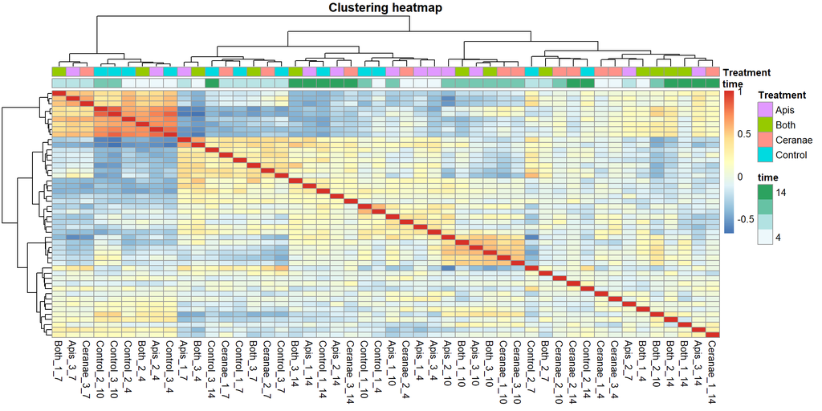

```r
sprDat <- transexpressionMatrix
sprDat <- sprDat[,-1]
sprDat <- t(scale(t(sprDat)))
sprDat <- na.omit(sprDat)
sprDat_cor <- cor(sprDat)
design <- meta_data
rownames(design) <- meta_data[,1]
design <- design[,-1]

# set pheatmap clustering parameters
clust_dist_col = "euclidean"
clust_method = "ward.D2"

#ClusteringHeatmap_treatment
pheatmap(sprDat_cor, cluster_rows = TRUE, scale = "none",
         clustering_method=clust_method,
         clustering_distance_cols = clust_dist_col,
         show_colnames = TRUE, show_rownames = FALSE,
         main = "Clustering heatmap",
         annotation = design[, c("time", "Treatment")])
```

A principal component analysis was conducted, and the percentage of total variance explained by each of the first six components plotted below. It appears that the first 3 principal components explain the bulk of the variation.

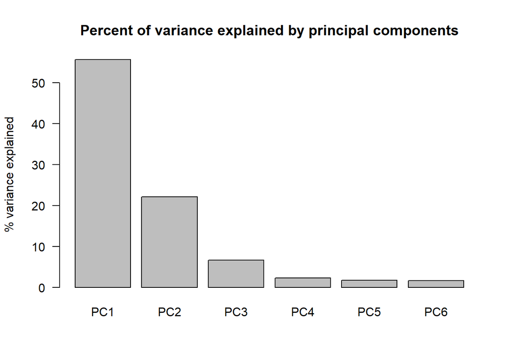

```r
# we can also use svd
svd <- svd(sprDat_cor)
percen <- svd$d ^ 2 /sum(svd$d ^ 2)*100
percen <- percen[c(1:6)]
names(percen) <- paste0("PC", 1:6)

barplot(percen, horiz = F, las = 1,
        ylab = "% variance explained",
        main = "Percent of variance explained by principal components")
```

The correlations between the first three principal components, “treatment”, and “time” are plotted below. It appears that the first principal component is correlated with “treatment”, and the third principal component is highly correlated with “time”.

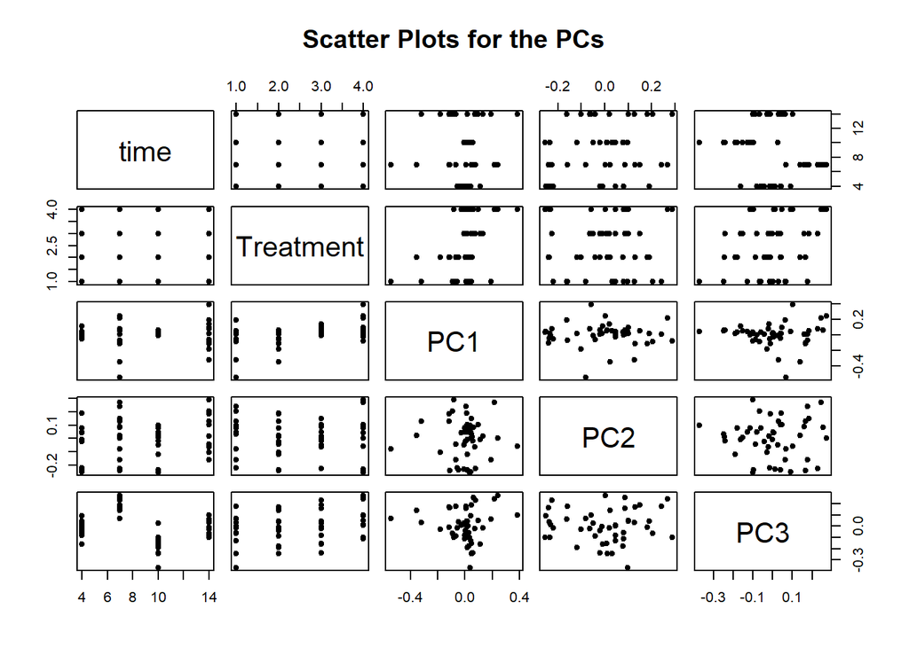

```r
pcs <- prcomp(sprDat, center = FALSE, scale = FALSE)

# append the rotations for the first 5 PCs
prinComp <- cbind(design, pcs$rotation[rownames(design), 1:5])

# scatter plot showing us how the first few PCs relate to covariates
plot(prinComp[, c("time", "Treatment", "PC1", "PC2", "PC3")],
     pch = 19, cex = 0.8, main = "Scatter Plots for the PCs")
```

Clustering of the samples by the first two principal components shows that “treatment”, especially Ceranae infected samples, are correlated with the first principal component.

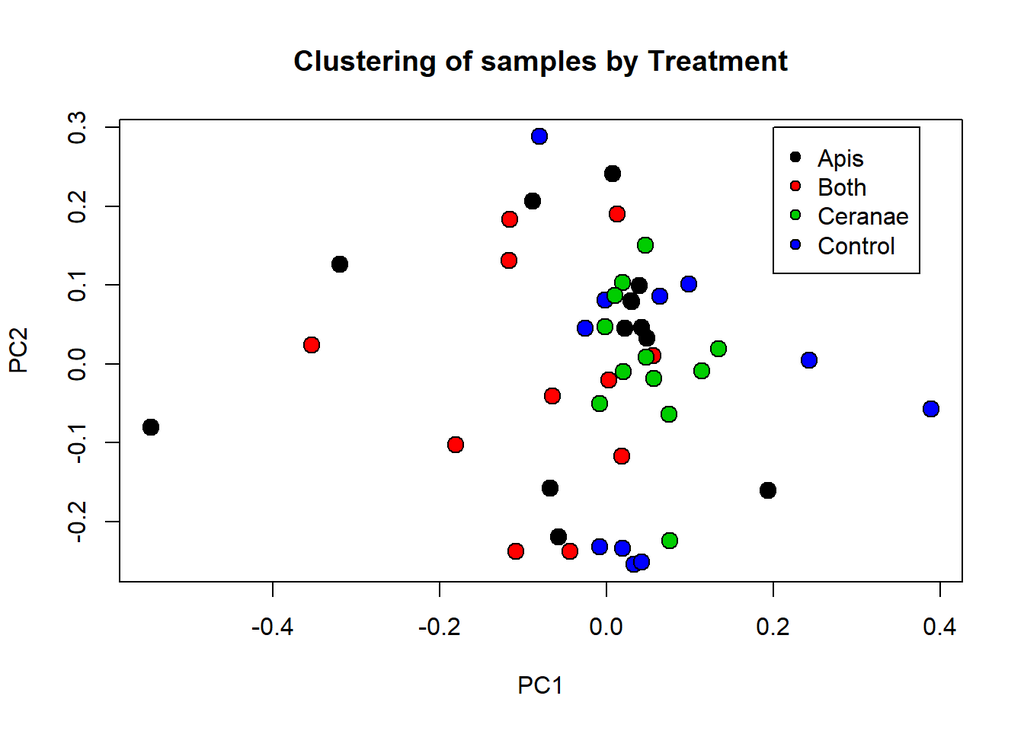

```r
# What does the samples spread look like, as explained by their first 2 principal components

plot(prinComp[, c("PC1", "PC2")], bg = design$Treatment,
     pch = 21, cex = 1.5, main = "Clustering of samples by Treatment")
legend(list(x = 0.2, y = 0.3), as.character(levels(design$Treatment)),
       pch = 21, pt.bg = c(1,2, 3, 4))
```

Clustering of the samples by the first and third principal components shows that “time” is highly correlated with the third principal component.

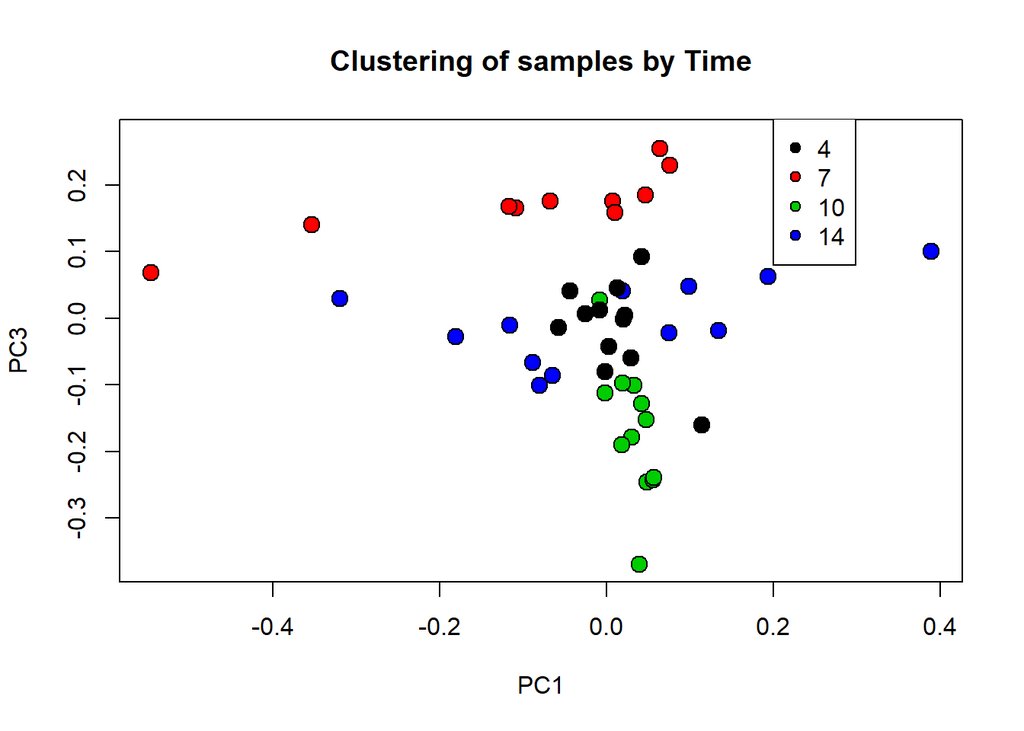

```r
design$time <- as.factor(design$time)
plot(prinComp[, c("PC1", "PC3")], bg = design$time, pch = 21, cex = 1.5,
     main = "Clustering of samples by Time")
legend(list(x = 0.2, y = 0.3), as.character(levels(design$time)),
       pch = 21, pt.bg = c(1,2, 3, 4))
```

We also made 3D plots for the first three principal components and the time/treatment. The 3D plots are dynamic. Also, you can double click on legend to isolate the individual trace.

```r
########## 3D plots ##################
# combine the treatment and the color
prinComp$time <- as.factor(prinComp$time)
plot_ly(prinComp, x = ~PC1, y = ~PC2, z = ~PC3, color = ~ Treatment,
        symbol = ~ time,
        symbols = c("diamond","circle","square", "cross"),
        mode="markers") %>%
  add_markers()
```

[interactive chart not shown]

```r
# just color the treatment
plot_ly(prinComp, x = ~PC1, y = ~PC2, z = ~PC3, color = ~ Treatment,
        mode="markers") %>%
  layout(title = 'Clustering of samples by Treatment')
```

[interactive chart not shown]

```r
# just color the time
plot_ly(prinComp, x = ~PC1, y = ~PC2, z = ~PC3, color = ~ time,
        mode="markers") %>%
  layout(title = 'Clustering of samples by Time (days)')
```

[interactive chart not shown]

Quantitatively assess the association of the treatment variable and time variable with all PCs up to PC3.

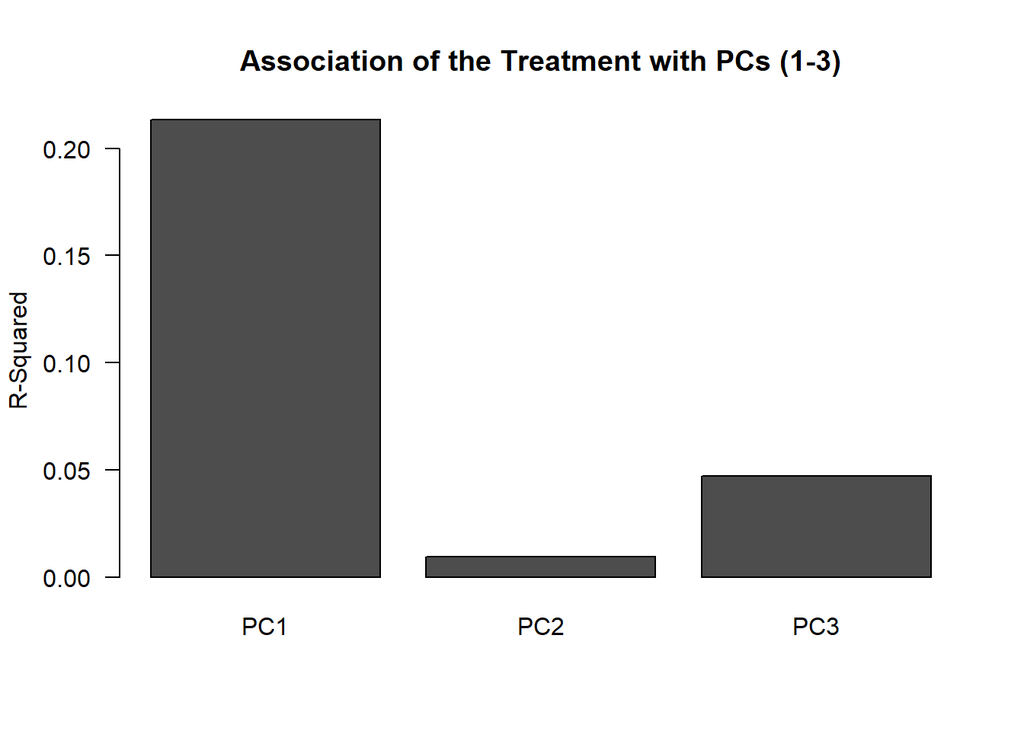

```r
r.squared <- c()
for(i in c(1:3)){
    lm.model <- eval(parse(text=(paste('lm(PC',i,'~Treatment,data=prinComp)',sep=''))))
    r.squared <- cbind(r.squared,summary(lm.model)$r.squared)
}

barplot(r.squared, las = 1, names.arg=c('PC1','PC2','PC3'),
        ylab="R-Squared", main = "Association of the Treatment with PCs (1-3)")
```

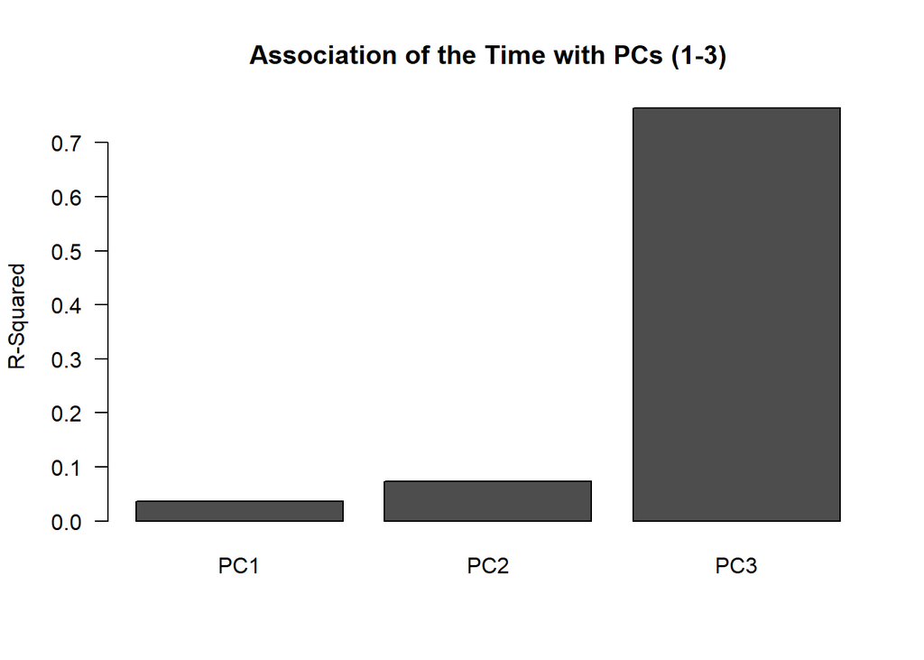

```r
r.squared <- c()
for(i in c(1:3)){
    lm.model <- eval(parse(text=(paste('lm(PC',i,'~time,data=prinComp)',sep=''))))
    r.squared <- cbind(r.squared,summary(lm.model)$r.squared)
}

barplot(r.squared, las = 1, names.arg=c('PC1','PC2','PC3'),
        ylab="R-Squared", main = "Association of the Time with PCs (1-3)")
```